# Data 605 HW5: Probability Distribution

Please refer to the [Assignment 5 Document](https://github.com/shirley-wong/Data-605/blob/master/Assignment5/hw5.pdf).

```r
library(tidyr)
library(dplyr)
```

# 1 Problem Set 1

Choose independently two numbers B and C at random from the interval [0,1] with uniform density. Prove that B and C are proper probability distributions. Note that the point (B,C) is then chosen at random in the unit square.

Find the probability that,

(a.) $B+C < \frac{1}{2}$

(b.) $BC < \frac{1}{2}$

(c.) $\left | B-C \right | < \frac{1}{2}$

(d.) $max \left \{ B,C \right \} < \frac{1}{2}$

(e.) $min \left \{ B,C \right \} < \frac{1}{2}$

## 1.1 General Ideas

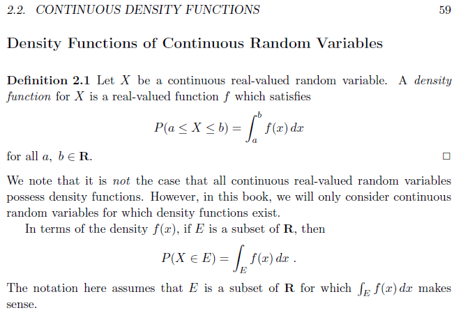

Def2.1 Density Functions of Continuous Random Variables from our Introduction to Probability textbook

## 1.2 Proof

By the Def2.1, let $X$ be a continuous real-valued random variable. The density function for $X$ is a real-valued function $f$ which satifies
$$P(a\leq X\leq b) = \int_{a}^{b}f(x)dx \; \; \; \; \; \; \;\forall a,b\in \mathbb{R}$$

The general formula for the probability density function of the uniform distribution is known as
$$f(x)=\frac{1}{b-a} \;\;\; for \;a\leq x\leq b$$

By substituting $a=0$ and $b=1$ into the above formula, we get

$$P(0\leq X\leq 1) = \int_{0}^{1}f(x)dx = \int_{0}^{1}\frac{1}{1-0}dx = \int_{0}^{1}1\; dx = 1-0=1$$
Therefore, the total probability of this density function equals to 1 and it satifies the definition of probability.

The cumulative distribution function of $X$ by definition is $F_{X}(x)=P(X \leq x)$. Based on the above distribution formula, we have
$$F_{X}(x) = P(X \leq x) = \int_{-\infty }^{x}f(x)dx = \int_{-\infty }^{x}1 \; dx = \left\{\begin{matrix}0, \;\;\;\;\;\;\;\;\; if\;\;\;x \leq 0\\ x, \;\;\; if\;\;0 \leq x \leq 1\\ 1, \;\;\;\;\;\;\;\;\; if \;\;\; x \leq 1\end{matrix}\right.$$

Since $B$ and $C$ are independently and randomly chosen from the interval $[0,1]$, we have
$$F_{X}(B) = P(X \leq B) =B$$
$$F_{X}(C) = P(X \leq C) =C$$

As all definitions and properties were able to apply to $B$ and $C$ and they are the cumulative distribution function of their own, I conclude that $B$ and $C$ are proper probability distributions.

## 1.3 Solve (a)

$P(B+C < \frac{1}{2})$

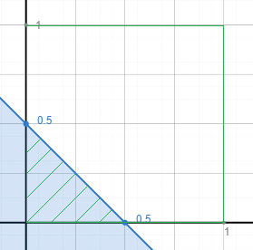

Graph 1a

Given that the point (B,C) is chosen at random in the unit square, let $x$ be $B$ and $y$ be $C$, we have

$$P(x+y<\frac{1}{2})$$
$$= P(y < \frac{1}{2}-x)$$
$$=\int_{0}^{1/2} \int_{0}^{1/2-x} f(x,y) \;dy\,dx$$
$$=\int_{0}^{1/2} \int_{0}^{1/2-x} 1 \; dy\,dx$$
$$=\int_{0}^{1/2} \frac{1}{2}-x\;dx$$
$$=\left [ \frac{x}{2} - \frac{x^{2}}{2} \right ]^{\frac{1}{2}}_{0}$$
$$=\frac{1}{4}-\frac{1}{4}\cdot\frac{1}{2}$$
$$=\frac{1}{8}$$

We can also easily solve the question by looking at the graph, **the probability = shaded area in green**
$$= \frac{(0.5)^{2}}{2}$$
$$=\frac{1}{8}$$

Verifying the result using the codes below:

```r
# setting up the inner function as 0*x+1 because integrate must take in a function with a variable
# `integrate` expects a vectorized function.
# the InnerFunc must accept a vector of inputs and produce a vector of function evaluations at those
# points, and the `Vectorize` function can be used to convert the InnerFunc to this form.

InnerFunc <- function(x) {0*x+1}
InnerIntegral <- Vectorize(function(y){integrate(InnerFunc,0,0.5-y)$value})
integrate(InnerIntegral, 0, 0.5)
```

```
## 0.125 with absolute error < 1.4e-15
```

```r
# reference: https://stackoverflow.com/questions/43189512/double-integral-in-r/43194274
```

## 1.4 Solve (b)

$P(BC < \frac{1}{2})$

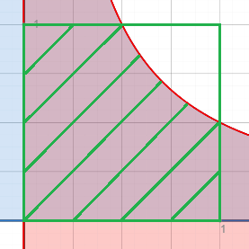

Graph 1b

Given that the point (B,C) is chosen at random in the unit square, let $x$ be $B$ and $y$ be $C$, we have

$$P(y < \frac{1}{2x})$$

$$= 1 - P(y > \frac{1}{2x})$$

$$= 1 - \int_{1/2}^{1} \int_{1/(2x)}^{1} 1 \;dy\,dx$$

$$=1 - \int_{1/2}^{1} 1-\frac{1}{2x} \;dx$$

$$=1 - (1-\frac{1}{2}) + \frac{1}{2}\cdot \left [ ln(x) \right ]^{1}_{1/2}$$
$$=\frac{1}{2} + \frac{1}{2} \cdot (ln(1)-ln(\frac{1}{2}))$$
$$=\frac{1}{2} + \frac{1}{2} \cdot (ln(1)-ln(1)+ln(2))$$
$$=\frac{1}{2} + \frac{ln(2)}{2}$$
$$\approx 0.84657359$$

Verifying the result using the codes below:

```r
# find the integral that is being deducted and minus it by 1
InnerFunc <- function(x) {0*x+1}
InnerIntegral <- Vectorize(function(y){integrate(InnerFunc,0.5/y,1)$value})
1-integrate(InnerIntegral, 0.5, 1)$value
```

```
## [1] 0.8465736
```

## 1.5 Solve (c)

$\left | B-C \right | < \frac{1}{2}$

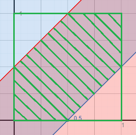

Graph 1c

Given that the point (B,C) is chosen at random in the unit square, let $x$ be $B$ and $y$ be $C$, we have

$$P(-\frac{1}{2} \leq x-y \leq \frac{1}{2})$$

$$= P(\,y<x+\frac{1}{2} \;\;\; \cap \;\;\; y>x-\frac{1}{2}) \;\;, for \;\;x,y\in \mathbb{[0,1]}$$
$$=\int_{0}^{1/2} \int_{0}^{x+1/2} 1 \;dy\,dx + \int_{1/2}^{1} \int_{x-1/2}^{1} 1 \;dy\,dx$$
$$= \int_{0}^{1/2} x+\frac{1}{2} \;dx + \int_{1/2}^{1} 1-x+\frac{1}{2} \;dx$$
$$= \left [ \frac{x^{2}}{2}+\frac{x}{2} \right ]^{1/2}_{0} + \left [ \frac{3x}{2} - \frac{x^{2}}{2} \right ]^{1}_{1/2}$$
$$= \frac{1}{8}+\frac{1}{4}+\frac{3}{2}-\frac{1}{2}-\frac{3}{4}+\frac{1}{8}$$
$$= \frac{3}{4}$$

We can also easily solve the question by looking at the graph, **the probability = shaded area in green**
$$=1 \cdot 1 - \frac{(\frac{1}{2})^{2}}{2} \cdot 2$$
$$= 1 - \frac{1}{4}$$
$$= \frac{3}{4}$$

Verifying the result using the codes below:

```r
# there are two integrals

# first integral
InnerFunc1 <- function(x) {0*x+1}
InnerIntegral1 <- Vectorize(function(y){integrate(InnerFunc1,0,y+0.5)$value})
#integrate(InnerIntegral1, 0, 0.5)

# second integral
InnerFunc2 <- function(x) {0*x+1}
InnerIntegral2 <- Vectorize(function(y){integrate(InnerFunc2,y-0.5,1)$value})
#integrate(InnerIntegral2, 0.5, 1)

# solution
integrate(InnerIntegral1, 0, 0.5)$value + integrate(InnerIntegral2, 0.5, 1)$value
```

```
## [1] 0.75
```

## 1.6 Solve (d)

$$max \left \{ B,C \right \} < \frac{1}{2}$$

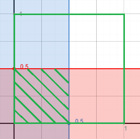

Graph 1d

Given that the point (B,C) is chosen at random in the unit square, let $x$ be $B$ and $y$ be $C$, we have

$$P(x<\frac{1}{2} \;\; \cap \;\; y<\frac{1}{2})$$
$$\int_{0}^{1/2}\int_{0}^{1/2} 1 \;dy\,dx$$

$$=(\frac{1}{2})^{2}$$
$$=\frac{1}{4}$$

Verifying the result using the codes below:

```r
InnerFunc <- function(x) {0*x+1}
InnerIntegral <- Vectorize(function(y){integrate(InnerFunc,0,0.5)$value})
integrate(InnerIntegral, 0, 0.5)
```

```
## 0.25 with absolute error < 2.8e-15
```

## 1.7 Solve (e)

$$min \left \{ B,C \right \} < \frac{1}{2}$$

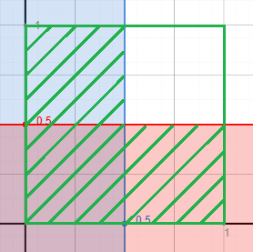

Graph 1e

Given that the point (B,C) is chosen at random in the unit square, let $x$ be $B$ and $y$ be $C$, we have

$$P(x<\frac{1}{2} \;\; \cup \;\; y<\frac{1}{2})$$
$$\int_{0}^{1/2}\int_{0}^{1} 1 \;dy\,dx + \int_{1/2}^{1}\int_{0}^{1/2} 1 \;dy\,dx$$

We can also easily solve the question by looking at the graph, **the probability = shaded area in green**
$$= (\frac{1}{2})^{2} \cdot 3$$
$$= \frac{3}{4}$$

Verifying the result using the codes below:

```r
# there are two integrals

# first integral
InnerFunc1 <- function(x) {0*x+1}
InnerIntegral1 <- Vectorize(function(y){integrate(InnerFunc1,0,1)$value})
#integrate(InnerIntegral1, 0, 0.5)

# second integral
InnerFunc2 <- function(x) {0*x+1}
InnerIntegral2 <- Vectorize(function(y){integrate(InnerFunc2,0,0.5)$value})
#integrate(InnerIntegral2, 0.5, 1)

# solution
integrate(InnerIntegral1, 0, 0.5)$value + integrate(InnerIntegral2, 0.5, 1)$value
```

```
## [1] 0.75
```